# HW 8

### SDS322E

## Simaak Siddiqi srs5826

**Please submit as a python notebook file on Canvas before the due date**

*For all questions, include the Python commands/functions that you used to find your answer. Answers without supporting code will not receive credit.*

### Libraries

Here I import the relevant libraries for your convinience, but feel free to make changes or import additional libraries, as needed.

```python
import numpy as np
import matplotlib.pyplot as plt
import pandas as pd
```

### Question 1. Dependency of Resistance of Materials to Temperature (12 pts)

Ohm's law states that the current through a conductor between two points is directly proportional to the voltage across the two points. Introducing a constant of proportionality, the resistance, one arrives at the usual mathematical expression that describes this relationship:

$$V = RI$$

where $I$ is the current through the conductor in units of amperes, $V$ is the voltage measured across the conductor in units of volts, and $R$ is the resistance of the conductor in units of ohms.

Resistance is an intrinsic property of any given material. There are many factors that can change the resistance of material including its "temperature." In an experiment, we want to study and model how the resistance changes with temperature at temperature close to zero Kelvin.

A scientist performs an experiment and measures the resistance of various materials at different temperatures. Now, a scientist asks you to use your ML expertise and fine a model that fits the data. The goal of this project is to practice regression modeling and evaluate the model using a set of visualizations.

### 1.1

First, load the dataset, `conductivity.csv`.

```python
conductivity = pd.read_csv('/stor/work/SDS322E_AF_Fall2023/data/conductivity.csv')
conductivity.head()
```

|  | T | R1 | R2 | R3 |
| --- | --- | --- | --- | --- |
| 0 | 1.089042 | 0.071018 | 3.108373 | 0.020145 |
| 1 | 2.436245 | 1.968973 | 3.819955 | 0.031398 |
| 2 | 3.491014 | 4.868741 | 21.414604 | -0.017774 |
| 3 | 4.742245 | 6.592862 | 29.233224 | 0.006610 |
| 4 | 5.304033 | 5.851338 | 6.427411 | -0.015857 |

### 1.2

In class we discussed `LinearRegression()`, use the `sklearn` documentation and describe the difference between `HuberRegressor()` and `LinearRegression()`. **[1 point]**

```python
from sklearn.linear_model import LinearRegression
from sklearn.linear_model import HuberRegressor
```

#### The Linear Regression in sklearn has mean squared error loss function, making it sensitive to outliers. The Huber Regressor offers increased robustness to outliers by mitigating their impact through a different loss function.

### 1.3

Use the `LinearRegression()` and `HuberRegressor()` methods from the `sklearn` library to fit a linear model to each material. Visualize your data **and** your fit with `matplotlib` library. You might want to consult with the `matplotlib` documentation. For each [T,R] pair you need to have two plots one per model, so in total you should have 6 plots. **[5 points]**

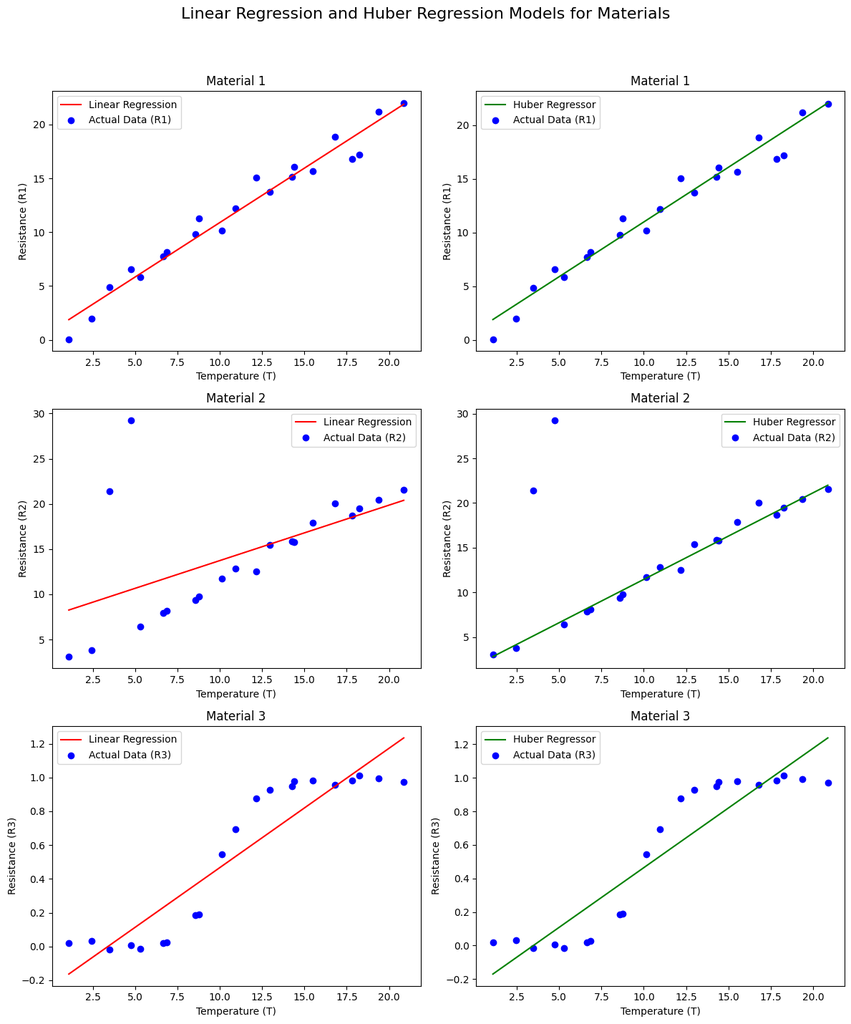

```python
import matplotlib.pyplot as plt
import numpy as np
from sklearn.linear_model import LinearRegression, HuberRegressor

# Assuming 'conductivity' is your DataFrame containing the dataset

# Extracting data
temperatures = conductivity['T'].values
resistances = conductivity[['R1', 'R2', 'R3']].values

# Create subplots
fig, axes = plt.subplots(nrows=3, ncols=2, figsize=(12, 15))
fig.suptitle('Linear Regression and Huber Regression Models for Materials', fontsize=16)

# Loop over each material (column in resistances)
for i, ax_row in enumerate(axes):
    # Linear Regression
    linear_model = LinearRegression()
    linear_model.fit(temperatures.reshape(-1, 1), resistances[:, i])
    linear_predictions = linear_model.predict(temperatures.reshape(-1, 1))

    ax_row[0].scatter(temperatures, resistances[:, i], label=f'Actual Data (R{i + 1})', color='blue')
    ax_row[0].plot(temperatures, linear_predictions, label='Linear Regression', color='red')
    ax_row[0].set_title(f'Material {i + 1}')
    ax_row[0].set_xlabel('Temperature (T)')
    ax_row[0].set_ylabel(f'Resistance (R{i + 1})')
    ax_row[0].legend()

    # Huber Regressor
    huber_model = HuberRegressor(epsilon=1.35)
    huber_model.fit(temperatures.reshape(-1, 1), resistances[:, i])
    huber_predictions = huber_model.predict(temperatures.reshape(-1, 1))

    ax_row[1].scatter(temperatures, resistances[:, i], label=f'Actual Data (R{i + 1})', color='blue')
    ax_row[1].plot(temperatures, huber_predictions, label='Huber Regressor', color='green')
    ax_row[1].set_title(f'Material {i + 1}')
    ax_row[1].set_xlabel('Temperature (T)')
    ax_row[1].set_ylabel(f'Resistance (R{i + 1})')
    ax_row[1].legend()

# Adjust layout for better spacing
plt.tight_layout(rect=[0, 0.03, 1, 0.95])

# Show the plots
plt.show()
```

### 1.4

Now let’s evaluate our model and interpret the results, **per material**. Visually speaking which model fits the data better? **[3 points]**

#### Generally speaking, the Huber Regressor fits better. For material 1, they are the same, for material 2, the outliers greatly affect the linear regression while the Huber fits well. The third material does not fit for both because both are still linear models that don't work well with nonlinear data.

### 1.5

Why do you think the `LinearRegression()` method failed for Material R2? Why do you think the `HuberRegressor()` method did not fail for Material R2? You may want to think about the key difference between the `LinearRegression()` and `HuberRegressor()` methods. You can consult with scikit-learn documentation. **[2 points]**

#### If Material R2 failed for the linear model but succeeded for the Huber model, it suggests that there might be outliers in the resistance data for Material R2. The outliers are clearly shown in the plots for material 2. This key difference comes from the loss functions, which quantifies how well the model's predictions match the actual target values. The linear regression uses MSE (mean squared error), which is succeptible to outliers, and the Huber model uses MSE and MAE (mean absolute error) which makes it more robust.

### 1.6

How do you justify the fact that `HuberRegressor()` could fit the data from materials R1 and R2 but not R3? Here, I want you to think about model misspecification and physics of this problem. You re-discovered superconductivity. **[1 points]**

#### The HuberRegressor, like other linear regression models, assumes a linear relationship between the input features and the target variable. If the underlying physics of Material R3 involves a non-linear relationship, such as an arctan-like relationship, the linear model may struggle to capture the true pattern. Furthermore, if there are physics-related occurences like critical temperature thresholds or phase transitions affecting the material's conductivity, a linear model may not capture these behaviors.

### Question 2: Separating stars and galaxies [8 points]

[figure not shown]

Modern astronomy and cosmology is concerned with the study and characterization of distant objects such as stars, galaxies, or quasars. Objects can often be very quickly characterized through detailed measurements of their optical spectrum. A spectrum is a measure of the photon flux (that is, the number of photons per second) as a function of photon frequency or wavelength.

The above spectrum is that of the star Vega, the brightest star in the northern constellation Lyra. Its surface temperature is about 9600 degrees Kelvin, and its spectrum is roughly that of a 9600K black-body, with absorption due to molecules in its atmosphere. Because of the quantum mechanical properties of atoms, different atoms can absorb light at only specific, discrete wavelengths. As such, characteristic patterns in the spectrum of a distant star can be used to infer its chemical composition! In the spectrum above, the deepest of these absorption spikes are due to the energy levels of Hydrogen. From examination of high-resolution spectra like this one, one can learn a lot about the physical processes at work in a distant astronomical source. Unfortunately, spectra like these are very time-consuming and expensive to obtain, especially for very faint objects. For this reason, astronomers have long observed objects through broad-band filters. For the u-band filter shown above, the flux is given by

[figure not shown]

$$f =\int f(\lambda) S(\lambda ) \frac{{\rm d}\lambda}{\lambda}$$

where $f(\lambda)$ is the filter transmission, and $S(\lambda)$ is the flux density of the spectrum at wavelength $\lambda$. For historical reasons, astronomers report the flux using the magnitude system, where the magnitude is defined by u=−2.5log10[f / 3631 [Jy]], where the denominator is a normalization constant, measured in the unit of Janskys. To reduce the uncertainties associated with absolute calibration from telescope to telescope or from night to night, astronomers generally work in terms of the color, defined as the difference of magnitudes between two different filter bands. Subtracting two magnitudes reduces this uncertainty. For example, an observation of the star Vega above will consist of a vector four numbers: [u-g, g-r, r-i, i-z], where u=ultraviolet, and r=red, i/z=infrared.

As an example, the study of quasars, an amalgamation of the words “quasi-stellar radio source”, has led to many advances in our understanding of fundamental physics. Quasars, also commonly referred to as QSOs (Quasi-Stellar Objects) or AGNs (Active Galactic Nuclei) are galaxies which contain supermassive black holes at their core. These black holes can weigh-in at over 10 billion times the mass of our sun, and can be luminous enough to out-shine their entire galaxy. From the images alone, it would be impossible to distinguish between the star and the quasar: both are unresolved point-sources of similar apparent brightness. If a spectrum were available, distinguishing between them could be accomplished rather straightforwardly, but spectra are not always available. Using multi-color photometric information, rather than just a single image, however, this task becomes feasible. The goal here is to design a classification algorithm which can accurately distinguish between galaxies, stars, and quasars based on multi-color photometric measurements.

```python
from sklearn.model_selection import train_test_split
from sklearn import metrics
import sklearn
import seaborn as sns
```

### 2.1

First read the data:

```python
df = pd.read_csv('/stor/work/SDS322E_AF_Fall2023/data/Skyserver_SQL.csv')
df.head()
```

|  | objid | ra | dec | u | g | r | i | z | run | rerun | camcol | field | specobjid | class | redshift | plate | mjd | fiberid |
| --- | --- | --- | --- | --- | --- | --- | --- | --- | --- | --- | --- | --- | --- | --- | --- | --- | --- | --- |
| 0 | 1.237650e+18 | 183.531326 | 0.089693 | 19.47406 | 17.04240 | 15.94699 | 15.50342 | 15.22531 | 752 | 301 | 4 | 267 | 3.722360e+18 | STAR | -0.000009 | 3306 | 54922 | 491 |
| 1 | 1.237650e+18 | 183.598370 | 0.135285 | 18.66280 | 17.21449 | 16.67637 | 16.48922 | 16.39150 | 752 | 301 | 4 | 267 | 3.638140e+17 | STAR | -0.000055 | 323 | 51615 | 541 |
| 2 | 1.237650e+18 | 183.680207 | 0.126185 | 19.38298 | 18.19169 | 17.47428 | 17.08732 | 16.80125 | 752 | 301 | 4 | 268 | 3.232740e+17 | GALAXY | 0.123111 | 287 | 52023 | 513 |
| 3 | 1.237650e+18 | 183.870529 | 0.049911 | 17.76536 | 16.60272 | 16.16116 | 15.98233 | 15.90438 | 752 | 301 | 4 | 269 | 3.722370e+18 | STAR | -0.000111 | 3306 | 54922 | 510 |
| 4 | 1.237650e+18 | 183.883288 | 0.102557 | 17.55025 | 16.26342 | 16.43869 | 16.55492 | 16.61326 | 752 | 301 | 4 | 269 | 3.722370e+18 | STAR | 0.000590 | 3306 | 54922 | 512 |

You can only use the columns [‘u’, ‘g’, ‘r’, ‘i’, ‘z’] to perform the classification task and the label column is `class`. We do not need the other columns. Thus the indepent variable should have 5 columns and the dependent variable should be the column `class`.

### 2.2

Construct the feature and dependent vectors. Then split the data randomly into training and test data sets. **[2 points]**

```python
# Selecting the relevant columns for features and target
features = df[['u', 'g', 'r', 'i', 'z']]
target = df['class']

# Splitting the data into training and test sets (80% training, 20% test)
X_train, X_test, y_train, y_test = train_test_split(features, target, test_size=0.2, random_state=42)
```

### 2.3

Use `sklearn` library and train 2 different classifiers of your choice using the training subset. **[3 points]**

```python
from sklearn.ensemble import RandomForestClassifier
from sklearn.svm import SVC
from sklearn.metrics import accuracy_score

# Instantiate the classifiers
random_forest = RandomForestClassifier(random_state=42)
svm_classifier = SVC(random_state=42)

# Train the Random Forest classifier
random_forest.fit(X_train, y_train)

# Train the Support Vector Machine classifier
svm_classifier.fit(X_train, y_train)

# Predictions on the training set
y_pred_rf_train = random_forest.predict(X_train)
y_pred_svm_train = svm_classifier.predict(X_train)
```

### 2.4

Evaluate the accuracy of your models on the test subset. **[1 points]**

```python
# Predictions on the test set
y_pred_rf_test = random_forest.predict(X_test)
y_pred_svm_test = svm_classifier.predict(X_test)

# Print accuracy on the test set
print("Random Forest Test Accuracy:", accuracy_score(y_test, y_pred_rf_test))
print("SVM Test Accuracy:", accuracy_score(y_test, y_pred_svm_test))
```

```
Random Forest Test Accuracy: 0.936
SVM Test Accuracy: 0.9395
```

### 2.5

Use scatter plot to visualize data in `x=g-z` and `y=g-r` space. Use different color to distinguish between different classes. Set `plt.ylim([-0.2, 1])` and `plt.xlim([-0.5, 2])`. What do you notice? **[2 points]**

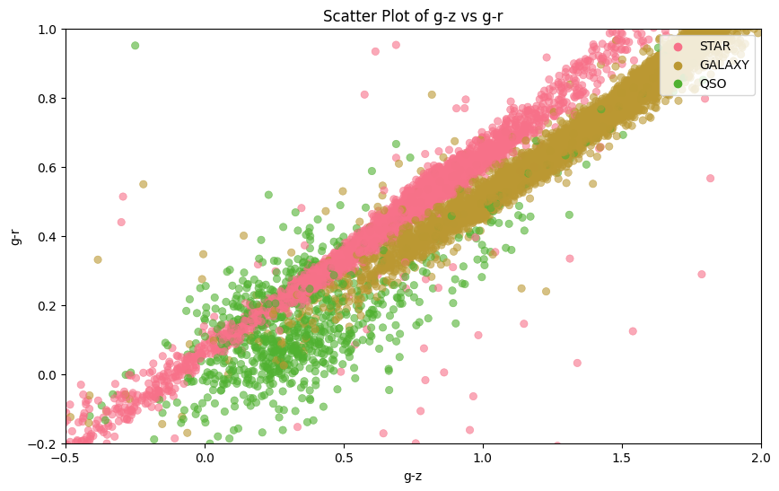

```python
# Add a new column 'g-z' and 'g-r' to the features dataframe
features['g-z'] = features['g'] - features['z']
features['g-r'] = features['g'] - features['r']

# Concatenate the features and target for plotting
plot_data = pd.concat([features[['g-z', 'g-r']], target], axis=1)

# Set the color palette for different classes
sns.set_palette("husl")

# Create a scatter plot
plt.figure(figsize=(10, 6))
sns.scatterplot(x='g-z', y='g-r', hue='class', data=plot_data, alpha=0.6, edgecolor=None)

# Set plot limits
plt.ylim([-0.2, 1])
plt.xlim([-0.5, 2])

# Set plot labels and title
plt.xlabel('g-z')
plt.ylabel('g-r')
plt.title('Scatter Plot of g-z vs g-r')

# Display the legend
plt.legend(loc='upper right')

# Show the plot
plt.show()
```